# Assignment 1: Machine Learning Model

# Lessons learned

The assignments gave us the opportunity to apply the methods we got to know during the lectures on real-world data. Working with GitHub for exchanging development progresses and Microsoft Teams for virtual meetups proved to be valuable, even more so under the special circumstances present today. As expected, the data preparation took at least as long as developing the models. Although we applied the methods learned during the courses, we found further RStudio functions that vastly assisted in pre-processing of the data. Without proper pre-processing, especially conversion of date and numeric attributes to their respective data type, any model development is futile. We overlooked some attributes in the beginning which led to weird predictions. Excluding near-zero variance predictors was a step we only learned to apply due to the warning messages of trained models. In the AI assignment we learned to not apply too many hidden layers (we sticked with 2) and 16 neurons per hidden layer are sufficient, in the context of binary cross-entropy.

Overall we found libraries during our research that massively helped us in the pre-processing step, such as knitr, and later on recipes. We had difficulties to run models with high numbers of cross-validations, which is something that should be kept in mind for the future. Overall, it was interesting to have a complete perspective on data science process, however we did not feel ready to tackle the assignment purely with the inputs from the lectures. Extensive research was required to properly understand all required pre-processing steps.

### Define, install and import used libraries

```r
libraries_used <- c("lazyeval", "readr","plyr" ,"dplyr", "readxl", "ggplot2",
    "funModeling", "scales", "tidyverse", "corrplot", "GGally", "caret",
    "rpart", "randomForest", "gbm", "choroplethr", "choroplethrMaps",
    "microbenchmark", "doParallel", "e1071")

libraries_missing <- libraries_used[!(libraries_used %in% installed.packages()[,"Package"])]
if(length(libraries_missing)) install.packages(libraries_missing)

library(dplyr)
library(recipes)
library(caret)
library(corrplot)
set.seed(1)
```

### Load Dataset

```r
df <- read.csv("regression_train_loan.csv")
```

### Extract meta information and output it

```r
meta_df <- funModeling::df_status( df, print_results = FALSE )

knitr::kable(meta_df)
```

| variable | q_zeros | p_zeros | q_na | p_na | q_inf | p_inf | type | unique |
| --- | --- | --- | --- | --- | --- | --- | --- | --- |
| X | 0 | 0.00 | 0 | 0.00 | 0 | 0 | integer | 798641 |
| id | 0 | 0.00 | 0 | 0.00 | 0 | 0 | integer | 798641 |
| member_id | 0 | 0.00 | 0 | 0.00 | 0 | 0 | integer | 798641 |
| loan_amnt | 0 | 0.00 | 0 | 0.00 | 0 | 0 | integer | 1372 |
| funded_amnt | 0 | 0.00 | 0 | 0.00 | 0 | 0 | integer | 1372 |
| funded_amnt_inv | 202 | 0.03 | 0 | 0.00 | 0 | 0 | numeric | 9040 |
| term | 0 | 0.00 | 0 | 0.00 | 0 | 0 | character | 2 |
| int_rate | 0 | 0.00 | 0 | 0.00 | 0 | 0 | numeric | 540 |
| installment | 0 | 0.00 | 0 | 0.00 | 0 | 0 | numeric | 66729 |
| grade | 0 | 0.00 | 0 | 0.00 | 0 | 0 | character | 7 |
| sub_grade | 0 | 0.00 | 0 | 0.00 | 0 | 0 | character | 35 |
| emp_title | 0 | 0.00 | 0 | 0.00 | 0 | 0 | character | 274363 |
| emp_length | 0 | 0.00 | 0 | 0.00 | 0 | 0 | character | 12 |
| home_ownership | 0 | 0.00 | 0 | 0.00 | 0 | 0 | character | 6 |
| annual_inc | 2 | 0.00 | 4 | 0.00 | 0 | 0 | numeric | 45904 |
| verification_status | 0 | 0.00 | 0 | 0.00 | 0 | 0 | character | 3 |
| issue_d | 0 | 0.00 | 0 | 0.00 | 0 | 0 | character | 103 |
| loan_status | 0 | 0.00 | 0 | 0.00 | 0 | 0 | character | 10 |
| pymnt_plan | 0 | 0.00 | 0 | 0.00 | 0 | 0 | character | 2 |
| url | 0 | 0.00 | 0 | 0.00 | 0 | 0 | character | 798641 |
| desc | 0 | 0.00 | 0 | 0.00 | 0 | 0 | character | 112107 |
| purpose | 0 | 0.00 | 0 | 0.00 | 0 | 0 | character | 14 |
| title | 0 | 0.00 | 0 | 0.00 | 0 | 0 | character | 57719 |
| zip_code | 0 | 0.00 | 0 | 0.00 | 0 | 0 | character | 931 |
| addr_state | 0 | 0.00 | 0 | 0.00 | 0 | 0 | character | 51 |
| dti | 403 | 0.05 | 0 | 0.00 | 0 | 0 | numeric | 4079 |
| delinq_2yrs | 645151 | 80.78 | 25 | 0.00 | 0 | 0 | integer | 29 |
| earliest_cr_line | 0 | 0.00 | 0 | 0.00 | 0 | 0 | character | 695 |
| inq_last_6mths | 448047 | 56.10 | 25 | 0.00 | 0 | 0 | integer | 25 |
| mths_since_last_delinq | 1526 | 0.19 | 408818 | 51.19 | 0 | 0 | integer | 154 |
| mths_since_last_record | 1144 | 0.14 | 675190 | 84.54 | 0 | 0 | integer | 123 |
| open_acc | 6 | 0.00 | 25 | 0.00 | 0 | 0 | integer | 74 |
| pub_rec | 676301 | 84.68 | 25 | 0.00 | 0 | 0 | integer | 29 |
| revol_bal | 3075 | 0.39 | 0 | 0.00 | 0 | 0 | numeric | 71446 |
| revol_util | 3210 | 0.40 | 454 | 0.06 | 0 | 0 | numeric | 1337 |
| total_acc | 0 | 0.00 | 25 | 0.00 | 0 | 0 | integer | 134 |
| initial_list_status | 0 | 0.00 | 0 | 0.00 | 0 | 0 | character | 2 |
| out_prncp | 230216 | 28.83 | 0 | 0.00 | 0 | 0 | numeric | 229320 |
| out_prncp_inv | 230216 | 28.83 | 0 | 0.00 | 0 | 0 | numeric | 245733 |
| total_pymnt | 15911 | 1.99 | 0 | 0.00 | 0 | 0 | numeric | 465319 |
| total_pymnt_inv | 16155 | 2.02 | 0 | 0.00 | 0 | 0 | numeric | 466355 |
| total_rec_prncp | 16251 | 2.03 | 0 | 0.00 | 0 | 0 | numeric | 241597 |
| total_rec_int | 16311 | 2.04 | 0 | 0.00 | 0 | 0 | numeric | 306708 |
| total_rec_late_fee | 787382 | 98.59 | 0 | 0.00 | 0 | 0 | numeric | 5699 |
| recoveries | 776435 | 97.22 | 0 | 0.00 | 0 | 0 | numeric | 20856 |
| collection_recovery_fee | 777490 | 97.35 | 0 | 0.00 | 0 | 0 | numeric | 18726 |
| last_pymnt_d | 0 | 0.00 | 0 | 0.00 | 0 | 0 | character | 99 |
| last_pymnt_amnt | 15822 | 1.98 | 0 | 0.00 | 0 | 0 | numeric | 215014 |
| next_pymnt_d | 0 | 0.00 | 0 | 0.00 | 0 | 0 | character | 100 |
| last_credit_pull_d | 0 | 0.00 | 0 | 0.00 | 0 | 0 | character | 103 |
| collections_12_mths_ex_med | 787941 | 98.66 | 126 | 0.02 | 0 | 0 | integer | 12 |
| mths_since_last_major_derog | 143 | 0.02 | 599107 | 75.02 | 0 | 0 | integer | 167 |
| policy_code | 0 | 0.00 | 0 | 0.00 | 0 | 0 | integer | 1 |
| application_type | 0 | 0.00 | 0 | 0.00 | 0 | 0 | character | 2 |
| annual_inc_joint | 0 | 0.00 | 798181 | 99.94 | 0 | 0 | numeric | 284 |
| dti_joint | 0 | 0.00 | 798183 | 99.94 | 0 | 0 | numeric | 407 |
| verification_status_joint | 0 | 0.00 | 0 | 0.00 | 0 | 0 | character | 4 |
| acc_now_delinq | 794889 | 99.53 | 25 | 0.00 | 0 | 0 | integer | 8 |
| tot_coll_amt | 630586 | 78.96 | 63276 | 7.92 | 0 | 0 | integer | 9850 |
| tot_cur_bal | 114 | 0.01 | 63276 | 7.92 | 0 | 0 | numeric | 311133 |
| open_acc_6m | 7398 | 0.93 | 779525 | 97.61 | 0 | 0 | integer | 13 |
| open_il_6m | 2098 | 0.26 | 779525 | 97.61 | 0 | 0 | integer | 31 |
| open_il_12m | 9696 | 1.21 | 779525 | 97.61 | 0 | 0 | integer | 12 |
| open_il_24m | 4930 | 0.62 | 779525 | 97.61 | 0 | 0 | integer | 17 |
| mths_since_rcnt_il | 12 | 0.00 | 780030 | 97.67 | 0 | 0 | integer | 200 |
| total_bal_il | 2047 | 0.26 | 779525 | 97.61 | 0 | 0 | integer | 15365 |
| il_util | 122 | 0.02 | 782007 | 97.92 | 0 | 0 | numeric | 1258 |
| open_rv_12m | 6333 | 0.79 | 779525 | 97.61 | 0 | 0 | integer | 17 |
| open_rv_24m | 2543 | 0.32 | 779525 | 97.61 | 0 | 0 | integer | 28 |
| max_bal_bc | 370 | 0.05 | 779525 | 97.61 | 0 | 0 | integer | 10100 |
| all_util | 14 | 0.00 | 779525 | 97.61 | 0 | 0 | numeric | 1119 |
| total_rev_hi_lim | 260 | 0.03 | 63276 | 7.92 | 0 | 0 | numeric | 19717 |
| inq_fi | 10231 | 1.28 | 779525 | 97.61 | 0 | 0 | integer | 17 |
| total_cu_tl | 10277 | 1.29 | 779525 | 97.61 | 0 | 0 | integer | 33 |
| inq_last_12m | 3563 | 0.45 | 779525 | 97.61 | 0 | 0 | integer | 29 |

### Get amount and percentage of unique

```r
meta_df_p <- meta_df %>% mutate(uniq_rat = unique / nrow(df))
meta_df_p %>% select(variable, unique, uniq_rat) %>% mutate(unique = unique, uniq_rat = scales::percent(uniq_rat)) %>% knitr::kable()
```

| variable | unique | uniq_rat |
| --- | --- | --- |
| X | 798641 | 100.00000% |
| id | 798641 | 100.00000% |
| member_id | 798641 | 100.00000% |
| loan_amnt | 1372 | 0.17179% |
| funded_amnt | 1372 | 0.17179% |
| funded_amnt_inv | 9040 | 1.13192% |
| term | 2 | 0.00025% |
| int_rate | 540 | 0.06761% |
| installment | 66729 | 8.35532% |
| grade | 7 | 0.00088% |
| sub_grade | 35 | 0.00438% |
| emp_title | 274363 | 34.35373% |
| emp_length | 12 | 0.00150% |
| home_ownership | 6 | 0.00075% |
| annual_inc | 45904 | 5.74776% |
| verification_status | 3 | 0.00038% |
| issue_d | 103 | 0.01290% |
| loan_status | 10 | 0.00125% |
| pymnt_plan | 2 | 0.00025% |
| url | 798641 | 100.00000% |
| desc | 112107 | 14.03722% |
| purpose | 14 | 0.00175% |
| title | 57719 | 7.22715% |
| zip_code | 931 | 0.11657% |
| addr_state | 51 | 0.00639% |
| dti | 4079 | 0.51074% |
| delinq_2yrs | 29 | 0.00363% |
| earliest_cr_line | 695 | 0.08702% |
| inq_last_6mths | 25 | 0.00313% |
| mths_since_last_delinq | 154 | 0.01928% |
| mths_since_last_record | 123 | 0.01540% |
| open_acc | 74 | 0.00927% |
| pub_rec | 29 | 0.00363% |
| revol_bal | 71446 | 8.94595% |
| revol_util | 1337 | 0.16741% |
| total_acc | 134 | 0.01678% |
| initial_list_status | 2 | 0.00025% |
| out_prncp | 229320 | 28.71378% |
| out_prncp_inv | 245733 | 30.76889% |
| total_pymnt | 465319 | 58.26385% |
| total_pymnt_inv | 466355 | 58.39357% |
| total_rec_prncp | 241597 | 30.25101% |
| total_rec_int | 306708 | 38.40374% |
| total_rec_late_fee | 5699 | 0.71359% |
| recoveries | 20856 | 2.61144% |
| collection_recovery_fee | 18726 | 2.34473% |
| last_pymnt_d | 99 | 0.01240% |
| last_pymnt_amnt | 215014 | 26.92248% |
| next_pymnt_d | 100 | 0.01252% |
| last_credit_pull_d | 103 | 0.01290% |
| collections_12_mths_ex_med | 12 | 0.00150% |
| mths_since_last_major_derog | 167 | 0.02091% |
| policy_code | 1 | 0.00013% |
| application_type | 2 | 0.00025% |
| annual_inc_joint | 284 | 0.03556% |
| dti_joint | 407 | 0.05096% |
| verification_status_joint | 4 | 0.00050% |
| acc_now_delinq | 8 | 0.00100% |
| tot_coll_amt | 9850 | 1.23335% |
| tot_cur_bal | 311133 | 38.95780% |
| open_acc_6m | 13 | 0.00163% |
| open_il_6m | 31 | 0.00388% |
| open_il_12m | 12 | 0.00150% |
| open_il_24m | 17 | 0.00213% |
| mths_since_rcnt_il | 200 | 0.02504% |
| total_bal_il | 15365 | 1.92389% |
| il_util | 1258 | 0.15752% |
| open_rv_12m | 17 | 0.00213% |
| open_rv_24m | 28 | 0.00351% |
| max_bal_bc | 10100 | 1.26465% |
| all_util | 1119 | 0.14011% |
| total_rev_hi_lim | 19717 | 2.46882% |
| inq_fi | 17 | 0.00213% |
| total_cu_tl | 33 | 0.00413% |
| inq_last_12m | 29 | 0.00363% |

### Convert Date attributes

```r
chr_to_date_vars <-  c("issue_d", "last_pymnt_d", "last_credit_pull_d", "next_pymnt_d", "earliest_cr_line", "next_pymnt_d")
convert_date <- function(x){
  as.Date(paste0("01-", x), format = "%d-%b-%Y")
}

df <- df %>% mutate_at(.funs = funs(convert_date), .vars = chr_to_date_vars)
```

[output not shown]

### Convert Numeric attributes

```r
chr_to_num_vars <-
  c("annual_inc_joint", "mths_since_last_major_derog", "open_acc_6m",
    "open_il_6m", "open_il_12m", "open_il_24m", "mths_since_rcnt_il",
    "total_bal_il", "il_util", "open_rv_12m", "open_rv_24m",
    "max_bal_bc", "all_util", "total_rev_hi_lim", "total_cu_tl",
    "inq_last_12m", "dti_joint", "inq_fi", "tot_cur_bal", "tot_coll_amt", "int_rate")

df <- df %>%  mutate_at(.funs = funs(as.numeric), .vars = chr_to_num_vars)
```

### Output a table with amount of unique, N/A, and zero values

```r
meta_df %>% select(variable, p_zeros, p_na, unique) %>% knitr::kable()
```

| variable | p_zeros | p_na | unique |
| --- | --- | --- | --- |
| X | 0.00 | 0.00 | 798641 |
| id | 0.00 | 0.00 | 798641 |
| member_id | 0.00 | 0.00 | 798641 |
| loan_amnt | 0.00 | 0.00 | 1372 |
| funded_amnt | 0.00 | 0.00 | 1372 |
| funded_amnt_inv | 0.03 | 0.00 | 9040 |
| term | 0.00 | 0.00 | 2 |
| int_rate | 0.00 | 0.00 | 540 |
| installment | 0.00 | 0.00 | 66729 |
| grade | 0.00 | 0.00 | 7 |
| sub_grade | 0.00 | 0.00 | 35 |
| emp_title | 0.00 | 0.00 | 274363 |
| emp_length | 0.00 | 0.00 | 12 |
| home_ownership | 0.00 | 0.00 | 6 |
| annual_inc | 0.00 | 0.00 | 45904 |
| verification_status | 0.00 | 0.00 | 3 |
| issue_d | 0.00 | 0.00 | 103 |
| loan_status | 0.00 | 0.00 | 10 |
| pymnt_plan | 0.00 | 0.00 | 2 |
| url | 0.00 | 0.00 | 798641 |
| desc | 0.00 | 0.00 | 112107 |
| purpose | 0.00 | 0.00 | 14 |
| title | 0.00 | 0.00 | 57719 |
| zip_code | 0.00 | 0.00 | 931 |
| addr_state | 0.00 | 0.00 | 51 |
| dti | 0.05 | 0.00 | 4079 |
| delinq_2yrs | 80.78 | 0.00 | 29 |
| earliest_cr_line | 0.00 | 0.00 | 695 |
| inq_last_6mths | 56.10 | 0.00 | 25 |
| mths_since_last_delinq | 0.19 | 51.19 | 154 |
| mths_since_last_record | 0.14 | 84.54 | 123 |
| open_acc | 0.00 | 0.00 | 74 |
| pub_rec | 84.68 | 0.00 | 29 |
| revol_bal | 0.39 | 0.00 | 71446 |
| revol_util | 0.40 | 0.06 | 1337 |
| total_acc | 0.00 | 0.00 | 134 |
| initial_list_status | 0.00 | 0.00 | 2 |
| out_prncp | 28.83 | 0.00 | 229320 |
| out_prncp_inv | 28.83 | 0.00 | 245733 |
| total_pymnt | 1.99 | 0.00 | 465319 |
| total_pymnt_inv | 2.02 | 0.00 | 466355 |
| total_rec_prncp | 2.03 | 0.00 | 241597 |
| total_rec_int | 2.04 | 0.00 | 306708 |
| total_rec_late_fee | 98.59 | 0.00 | 5699 |
| recoveries | 97.22 | 0.00 | 20856 |
| collection_recovery_fee | 97.35 | 0.00 | 18726 |
| last_pymnt_d | 0.00 | 0.00 | 99 |
| last_pymnt_amnt | 1.98 | 0.00 | 215014 |
| next_pymnt_d | 0.00 | 0.00 | 100 |
| last_credit_pull_d | 0.00 | 0.00 | 103 |
| collections_12_mths_ex_med | 98.66 | 0.02 | 12 |
| mths_since_last_major_derog | 0.02 | 75.02 | 167 |
| policy_code | 0.00 | 0.00 | 1 |
| application_type | 0.00 | 0.00 | 2 |
| annual_inc_joint | 0.00 | 99.94 | 284 |
| dti_joint | 0.00 | 99.94 | 407 |
| verification_status_joint | 0.00 | 0.00 | 4 |
| acc_now_delinq | 99.53 | 0.00 | 8 |
| tot_coll_amt | 78.96 | 7.92 | 9850 |
| tot_cur_bal | 0.01 | 7.92 | 311133 |
| open_acc_6m | 0.93 | 97.61 | 13 |
| open_il_6m | 0.26 | 97.61 | 31 |
| open_il_12m | 1.21 | 97.61 | 12 |
| open_il_24m | 0.62 | 97.61 | 17 |
| mths_since_rcnt_il | 0.00 | 97.67 | 200 |
| total_bal_il | 0.26 | 97.61 | 15365 |
| il_util | 0.02 | 97.92 | 1258 |
| open_rv_12m | 0.79 | 97.61 | 17 |
| open_rv_24m | 0.32 | 97.61 | 28 |
| max_bal_bc | 0.05 | 97.61 | 10100 |
| all_util | 0.00 | 97.61 | 1119 |
| total_rev_hi_lim | 0.03 | 7.92 | 19717 |
| inq_fi | 1.28 | 97.61 | 17 |
| total_cu_tl | 1.29 | 97.61 | 33 |
| inq_last_12m | 0.45 | 97.61 | 29 |

### Remove columns deemed unfit for modeling

```r
vars_to_remove <- c("annual_inc_joint", "dti_joint", "policy_code", "id", "member_id",
                    "emp_title", "url", "desc", "title", "open_acc_6m", "open_il_6m",
                    "open_il_12m", "open_il_24m", "mths_since_rcnt_il", "total_bal_il",
                    "il_util", "open_rv_12m", "open_rv_24m", "max_bal_bc", "all_util",
                    "total_rev_hi_lim", "inq_fi", "total_cu_tl", "inq_last_12m",
                    "verification_status_joint", "next_pymnt_d", "sub_grade", "X", "zip_code", "application_type",
                    "mths_since_last_major_derog", "last_pymnt_d", "last_credit_pull_d", "issue_d", "delinq_2yrs", "inq_last_6mths", "total_rec_int",
                    "total_rec_late_fee", "last_pymnt_amnt")

df <- df %>% select(-one_of(vars_to_remove))
```

### Convert “term” column to number

```r
df$term <- as.numeric(gsub( ".*([0-9]+).*", "\\1", df$term ))
```

### Convert “emp_length” to numeric values

```r
df$emp_length[df$emp_length == "n/a"] <- 99
df$emp_length[df$emp_length == "< 1 year"] <- 0
df$emp_length <- as.numeric(gsub( "([0-9]+).*", "\\1", df$emp_length ))
```

### Output numerical vars

```r
num_vars <-
  df %>%
  sapply(is.numeric) %>%
  which() %>%
  names()

meta_df <- funModeling::df_status(df, print_results = FALSE)

meta_df %>%
  select(variable, p_zeros, p_na, unique) %>%
  filter_(~ variable %in% num_vars) %>%
  knitr::kable()
```

```
`filter_()` is deprecated as of dplyr 0.7.0.
Please use `filter()` instead.
See vignette('programming') for more help
```

| variable | p_zeros | p_na | unique |
| --- | --- | --- | --- |
| loan_amnt | 0.00 | 0.00 | 1372 |
| funded_amnt | 0.00 | 0.00 | 1372 |
| funded_amnt_inv | 0.03 | 0.00 | 9040 |
| term | 30.00 | 0.00 | 2 |
| int_rate | 0.00 | 0.00 | 540 |
| installment | 0.00 | 0.00 | 66729 |
| emp_length | 7.95 | 0.00 | 12 |
| annual_inc | 0.00 | 0.00 | 45904 |
| dti | 0.05 | 0.00 | 4079 |
| mths_since_last_delinq | 0.19 | 51.19 | 154 |
| mths_since_last_record | 0.14 | 84.54 | 123 |
| open_acc | 0.00 | 0.00 | 74 |
| pub_rec | 84.68 | 0.00 | 29 |
| revol_bal | 0.39 | 0.00 | 71446 |
| revol_util | 0.40 | 0.06 | 1337 |
| total_acc | 0.00 | 0.00 | 134 |
| out_prncp | 28.83 | 0.00 | 229320 |
| out_prncp_inv | 28.83 | 0.00 | 245733 |
| total_pymnt | 1.99 | 0.00 | 465319 |
| total_pymnt_inv | 2.02 | 0.00 | 466355 |
| total_rec_prncp | 2.03 | 0.00 | 241597 |
| recoveries | 97.22 | 0.00 | 20856 |
| collection_recovery_fee | 97.35 | 0.00 | 18726 |
| collections_12_mths_ex_med | 98.66 | 0.02 | 12 |
| acc_now_delinq | 99.53 | 0.00 | 8 |
| tot_coll_amt | 78.96 | 7.92 | 9850 |
| tot_cur_bal | 0.01 | 7.92 | 311133 |

### Correlation plot

First step to get an overview of potential collinearities. Failing to identify multicollinearity could result in misleading interpretations of the results.

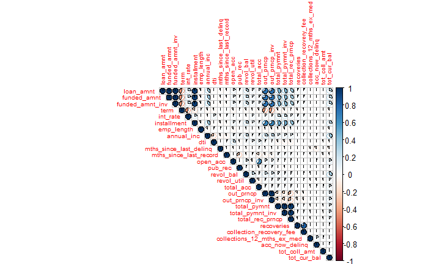

```r
corrplot::corrplot(cor(df[, num_vars], use = "complete.obs"),
                   method = "pie", type = "upper",tl.cex = 0.65)
```

### Display highly correlated variables

We want to identify collinearities which could affect our regression model. A Cut-off at 0.5 is applied.

```r
caret::findCorrelation(cor(df[, num_vars], use = "complete.obs"),
                       names = TRUE, cutoff = .5)
```

```
[1] "funded_amnt"     "loan_amnt"       "funded_amnt_inv" "installment"     "out_prncp"       "total_pymnt_inv" "total_pymnt"     "open_acc"
[9] "recoveries"
```

### Remove highly correlated variables to avoid the interference of collinearity in our model

Multicollinearity arises when at least two highly correlated predictors are assessed simultaneously in a regression model.

```r
vars_to_remove <-
  c("loan_amnt", "funded_amnt", "funded_amnt_inv", "installment", "total_pymnt_inv",
    "out_prncp", "total_pymnt", "total_rec_prncp", "total_acc",
    "mths_since_last_record",  "mths_since_last_delinq", "recoveries")

df <- df %>% select(-one_of(vars_to_remove))
```

```r
df <- df[complete.cases(df), ]
```

### Recreate meta table

```r
meta_df <- funModeling::df_status(df, print_results = FALSE)
knitr::kable( meta_df )
```

| variable | q_zeros | p_zeros | q_na | p_na | q_inf | p_inf | type | unique |
| --- | --- | --- | --- | --- | --- | --- | --- | --- |
| term | 224925 | 30.60 | 0 | 0 | 0 | 0 | numeric | 2 |
| int_rate | 0 | 0.00 | 0 | 0 | 0 | 0 | numeric | 199 |
| grade | 0 | 0.00 | 0 | 0 | 0 | 0 | character | 7 |
| emp_length | 56781 | 7.73 | 0 | 0 | 0 | 0 | numeric | 12 |
| home_ownership | 0 | 0.00 | 0 | 0 | 0 | 0 | character | 6 |
| annual_inc | 2 | 0.00 | 0 | 0 | 0 | 0 | numeric | 42902 |
| verification_status | 0 | 0.00 | 0 | 0 | 0 | 0 | character | 3 |
| loan_status | 0 | 0.00 | 0 | 0 | 0 | 0 | character | 8 |
| pymnt_plan | 0 | 0.00 | 0 | 0 | 0 | 0 | character | 2 |
| purpose | 0 | 0.00 | 0 | 0 | 0 | 0 | character | 14 |
| addr_state | 0 | 0.00 | 0 | 0 | 0 | 0 | character | 51 |
| dti | 186 | 0.03 | 0 | 0 | 0 | 0 | numeric | 4079 |
| earliest_cr_line | 78 | 0.01 | 0 | 0 | 0 | 0 | Date | 691 |
| open_acc | 0 | 0.00 | 0 | 0 | 0 | 0 | integer | 73 |
| pub_rec | 615612 | 83.75 | 0 | 0 | 0 | 0 | integer | 29 |
| revol_bal | 1636 | 0.22 | 0 | 0 | 0 | 0 | numeric | 69850 |
| revol_util | 2074 | 0.28 | 0 | 0 | 0 | 0 | numeric | 1248 |
| initial_list_status | 0 | 0.00 | 0 | 0 | 0 | 0 | character | 2 |
| out_prncp_inv | 170255 | 23.16 | 0 | 0 | 0 | 0 | numeric | 242665 |
| collection_recovery_fee | 720460 | 98.02 | 0 | 0 | 0 | 0 | numeric | 14349 |
| collections_12_mths_ex_med | 724445 | 98.56 | 0 | 0 | 0 | 0 | integer | 12 |
| acc_now_delinq | 731295 | 99.49 | 0 | 0 | 0 | 0 | integer | 8 |
| tot_coll_amt | 630268 | 85.75 | 0 | 0 | 0 | 0 | numeric | 9848 |
| tot_cur_bal | 102 | 0.01 | 0 | 0 | 0 | 0 | numeric | 311024 |

### Set the training and test data (80% train, 20% test)

```r
train_index <- caret::createDataPartition(y = df$int_rate, times = 1, p = .8, list = FALSE)

train <- df[train_index, ]
test <- df[-train_index, ]
```

### Data preprocessing

The following steps are executed:

```r
recipe_obj <- recipe( int_rate ~ ., data = train ) %>%
  step_nzv(all_predictors()) %>%
  step_date( has_type( match = "date" ) ) %>%
  step_rm( has_type( match = "date" ) ) %>%
  step_dummy( all_nominal(), -all_outcomes() ) %>%
  step_normalize( all_predictors() )

recipe_obj
```

```
Data Recipe

Inputs:
```

| role | #variables |
| --- | --- |
| outcome | 1 |
| predictor | 23 |

```
Operations:

Sparse, unbalanced variable filter on all_predictors()
Date features from has_type(match = "date")
Delete terms has_type(match = "date")
Dummy variables from all_nominal(), -all_outcomes()
Centering and scaling for all_predictors()
```

### Define the resampling method for model training

We apply a 10-time cross validation for our regression models.

```r
fitControl <- trainControl(method = "cv", verboseIter = TRUE)
```

### Train linear regression model

```r
model <- train(recipe_obj, data = train,
               method = "lm",
               tuneLength = 10,
               trControl = fitControl)
```

```
Preparing recipe
```

```
There are new levels in a factor: ANYThere are new levels in a factor: ANY
```

```
There are new levels in a factor: educationalThere are new levels in a factor: IAThere are new levels in a factor: educationalThere are new levels in a factor: IA
```

```r
summary(model)
```

```
Call:
lm(formula = .outcome ~ ., data = dat)

Residuals:
     Min       1Q   Median       3Q      Max
-17.7427  -0.8746   0.0118   0.8239   7.2627

Coefficients:
                                      Estimate Std. Error  t value Pr(>|t|)
(Intercept)                         13.3013713  0.0015066 8828.627  < 2e-16 ***
term                                -0.2004638  0.0019197 -104.425  < 2e-16 ***
emp_length                          -0.0389245  0.0015957  -24.393  < 2e-16 ***
annual_inc                          -0.0013940  0.0017263   -0.807 0.419382
dti                                 -0.0129726  0.0015616   -8.307  < 2e-16 ***
open_acc                             0.0182730  0.0016597   11.010  < 2e-16 ***
pub_rec                             -0.0077956  0.0015514   -5.025 5.04e-07 ***
revol_bal                           -0.0085094  0.0018087   -4.705 2.54e-06 ***
revol_util                           0.1721098  0.0017027  101.082  < 2e-16 ***
out_prncp_inv                       -0.2724755  0.0022590 -120.618  < 2e-16 ***
tot_cur_bal                         -0.0406829  0.0021000  -19.373  < 2e-16 ***
earliest_cr_line_year               -0.0170235  0.0016301  -10.443  < 2e-16 ***
grade_B                              1.4902760  0.0022079  674.985  < 2e-16 ***
grade_C                              2.8743167  0.0023628 1216.472  < 2e-16 ***
grade_D                              3.4834441  0.0022464 1550.704  < 2e-16 ***
grade_E                              3.3296060  0.0020627 1614.215  < 2e-16 ***
grade_F                              2.5205137  0.0017618 1430.608  < 2e-16 ***
grade_G                              1.3934634  0.0015814  881.144  < 2e-16 ***
home_ownership_MORTGAGE             -0.7610927  0.5778367   -1.317 0.187792
home_ownership_NONE                 -0.0073803  0.0090427   -0.816 0.414412
home_ownership_OTHER                -0.0044453  0.0085256   -0.521 0.602083
home_ownership_OWN                  -0.4575411  0.3474205   -1.317 0.187850
home_ownership_RENT                 -0.7455747  0.5648983   -1.320 0.186889
verification_status_Source.Verified  0.0393229  0.0018574   21.171  < 2e-16 ***
verification_status_Verified         0.1812199  0.0019181   94.480  < 2e-16 ***
loan_status_Current                 -0.2777293  0.0036146  -76.835  < 2e-16 ***
loan_status_Default                 -0.0055608  0.0015347   -3.623 0.000291 ***
loan_status_Fully.Paid              -0.0765389  0.0031739  -24.115  < 2e-16 ***
loan_status_In.Grace.Period         -0.0329501  0.0016496  -19.975  < 2e-16 ***
loan_status_Issued                  -0.0764193  0.0017282  -44.219  < 2e-16 ***
loan_status_Late..16.30.days.       -0.0192940  0.0015638  -12.338  < 2e-16 ***
```

[output cut: 73 more lines]

```
earliest_cr_line_month_Apr          -0.0109428  0.0020638   -5.302 1.14e-07 ***
earliest_cr_line_month_May          -0.0073107  0.0020758   -3.522 0.000429 ***
earliest_cr_line_month_Jun          -0.0098294  0.0020751   -4.737 2.17e-06 ***
earliest_cr_line_month_Jul          -0.0107244  0.0020924   -5.125 2.97e-07 ***
earliest_cr_line_month_Aug          -0.0197635  0.0021959   -9.000  < 2e-16 ***
earliest_cr_line_month_Sep          -0.0160494  0.0021910   -7.325 2.39e-13 ***
earliest_cr_line_month_Oct          -0.0129407  0.0021840   -5.925 3.12e-09 ***
earliest_cr_line_month_Nov          -0.0063322  0.0021332   -2.968 0.002993 **
earliest_cr_line_month_Dec          -0.0014728  0.0020942   -0.703 0.481867
---
Signif. codes:  0 ‘***’ 0.001 ‘**’ 0.01 ‘*’ 0.05 ‘.’ 0.1 ‘ ’ 1

Residual standard error: 1.155 on 587902 degrees of freedom
Multiple R-squared:  0.9313,    Adjusted R-squared:  0.9313
F-statistic: 7.118e+04 on 112 and 587902 DF,  p-value: < 2.2e-16
```

### Generate predictions and display RMSE, Rsquared and MAE

```r
test_results <- data.frame(Class = test$int_rate)
test_results$predicted.int_rate <- predict(model, test)

postResample(pred = test_results$predicted.int_rate, obs = test$int_rate)
```

```
     RMSE  Rsquared       MAE
1.1526023 0.9315439 0.9420718
```

### Show the test set results

```r
head(test_results)
```

|  | Class | predicted.int_rate |
| --- | --- | --- |
| 1 | 6.03 | 7.811663 |
| 2 | 8.90 | 8.099580 |
| 3 | 11.14 | 10.698771 |
| 4 | 6.24 | 7.054282 |
| 5 | 18.25 | 18.310748 |
| 6 | 11.55 | 11.155755 |

### Save the required data to the filesystem

```r
saveRDS(model_ml_lm, "model.lm")
write.csv(train_filtered, "ml_train.csv", row.names = TRUE)
write.csv(test, "ml_test.csv", row.names = TRUE)
```